# Working Draft

Patrick McKenzie & Rachel Swenie

April 24, 2017

# Biogeography Model

Using data matrices, movement function, and speciation function to reconstruct ancestral ranges.

# Sample tree

(A:1000,((B:400,C:400):200,(D:200,E:200):400):400);

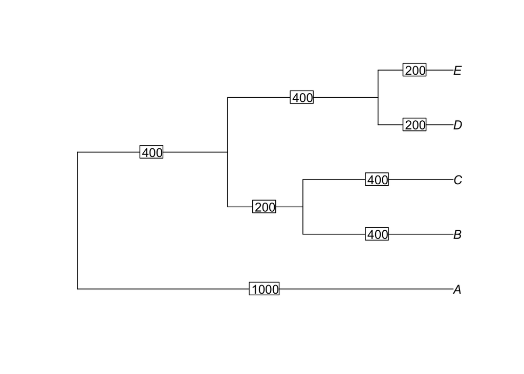

# Generate a species range in a matrix with this cool function

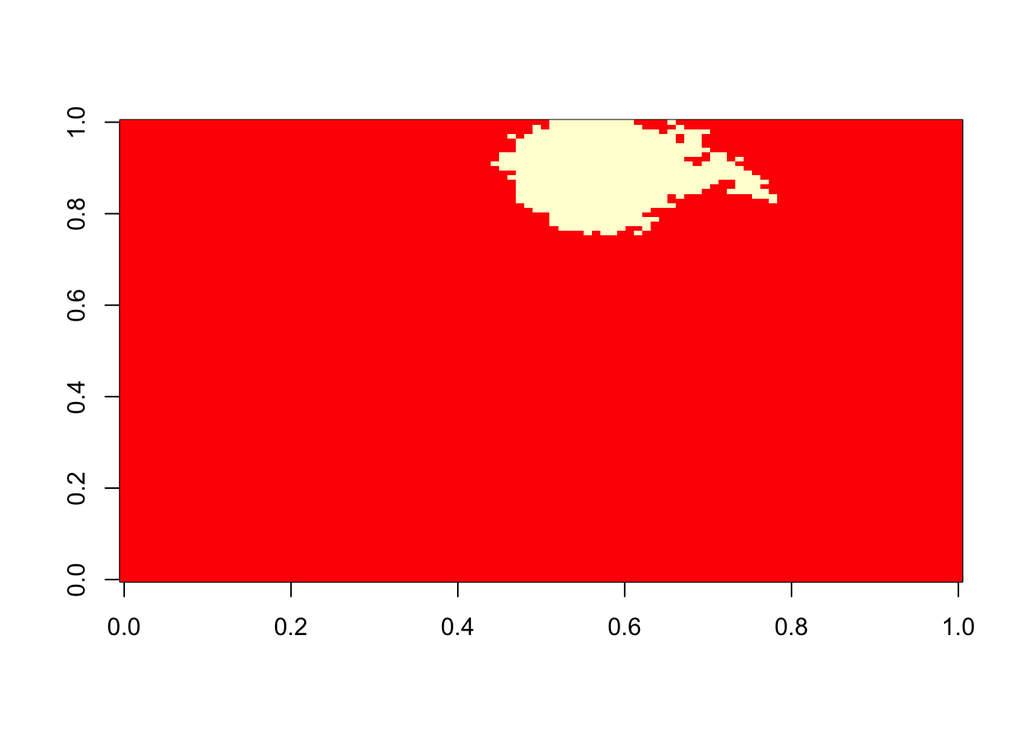

```r
get_random_species_range <- function(nrow, ncol, numbercells, startingcell = NULL) {
  rows <- nrow
  cols <- ncol
  randommatrix <- matrix(rep(0,rows*cols), nrow = rows, ncol = cols)
  if (is.null(startingcell)) {
    index <- sample(rows*cols,1)
    randommatrix[index] <- 1
    pointindices <- arrayInd(index,c(rows,cols))
  } else {
    pointindices <- startingcell
    dim(pointindices) <- c(1,2)
  }

  while(sum(randommatrix) < numbercells) {
  workingcell <- pointindices[sample(nrow(pointindices),1),]
  random_adjacent <- sample(c(-1:1),2,replace = TRUE) #new cell row and col
  check_occupancy <- workingcell + random_adjacent
  if (sum(check_occupancy > 0) == 2 && sum(check_occupancy <= c(rows,cols)) == 2) {
    if (randommatrix[check_occupancy[1],check_occupancy[2]] == 0) {
      randommatrix[check_occupancy[1],check_occupancy[2]] <- 1
      pointindices <- rbind(pointindices,check_occupancy)
    }
  }
  }
  randommatrix
}

example_range <- get_random_species_range(100,100,500)
image(example_range)
```

# Movement and speciation

For each step in time, the following eqation is applied to each cell to calculate its new “probability” value. * These are normalized at each node and no longer represent true probabilities when moving up the tree.

$$P_{s,x,y}(t-1) = E_{x,y}(t-1)(((1-P_{s,x,y}(t))*\alpha*\frac{\bar{N}}{8}) + (P_{s,x,y}(t)*\beta*\frac{\bar{N}}{8}))$$

The same equation is written out in code below. Note that `get_Nbar()` is a separate function written to calculate $\bar{N}$.

```r
get_prob_matrix <- function(Ps,Es, alpha, beta) {
  probs_older <- Ps
  for (i in 1:nrow(Ps)) { # rows
    for (q in 1:ncol(Ps)) { # columns
      Pcell <- Ps[i,q]
      Ecell <- Es[i,q]
      Nbar <- get_Nbar(Ps,i,q)
      Polder <- Ecell * ( ( (1-Pcell) * (Nbar/8) * alpha) + (Pcell * (Nbar/8) * beta) )
      probs_older[i,q] <- Polder
    }
  }
  probs_older
}
```

When a node is reached (moving from tips to root), the probability matrix for each lineage is normalized, and the two matrices are multiplied together.

# Scenario 1: Homogeneous environment

(A:1000,((B:400,C:400):200,(D:200,E:200):400):400)

```r
Es <- matrix(nrow = 10,ncol = 10)
Es[1:100] <- 1

speciesA <- get_random_species_range(100,100, 100)
image(speciesA,main="SpeciesA Range")
speciesB <- get_random_species_range(100,100, 500)
image(speciesB,main = "SpeciesB Range")
speciesC <- get_random_species_range(100,100, 100)
image(speciesC,main = "SpeciesC Range")
speciesD <- get_random_species_range(100,100, 500)
image(speciesD,main="SpeciesD Range")
speciesE <- get_random_species_range(100,100, 100)
image(speciesE,main="SpeciesE Range")
```

[output not shown]